# Análisis de posición del mecanismo manivela corredera por métodos numéricos

## Objetivo

Encontrar valores de las variables del mecanismo que me permitan posicionar sus barras, usando métodos numéricos.

## Diagramas cinemático y vectorial

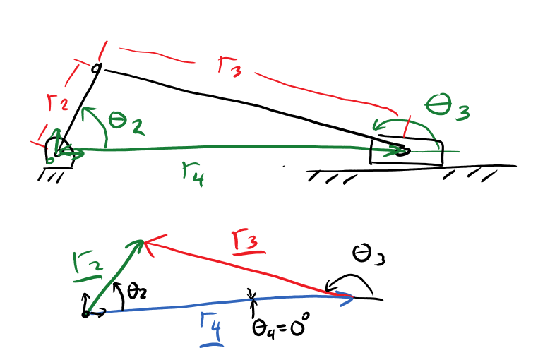

Usar este enlace para escribir las ecuaciones en formáto LaTeX: https://codecogs.com/latex/eqneditor.php

Parámetros: $r2$, $r3$, $\theta_4$

Variable de entrada: $\theta_2$

Variables secundarias: $\theta_3$ y $r_4$

A partir del diagrama vectorial, se puede plantear una ecuación vectorial que represente al mecanismo:

$\overrightarrow{r_{2}}-\overrightarrow{r_{3}}-\overrightarrow{r_{4}} = 0$ (1)

cuyas ecuaciones escalares son

$r2\cdot cos(\theta_{2})-r3\cdot cos(\theta_{3})-r4\cdot cos(\theta_{4})=0$, (2)

$r2\cdot sin(\theta_{2})-r3\cdot sin(\theta_{3})-r4\cdot sin(\theta_{4})=0$ (3).

El problema ahora consiste en resolver este sistema de ecuaciones NO LINEAL. Para esto usaremos el módulo de optimización de Scipy, específicamente la función fsolve.

## Solución

Primero importamos los módulos necesarios:

1. numpy para operaciones numéricas
2. fsolve de scipy.optimize para resolver el sistema de ecuaciones no lineal

```python
import numpy as np
from scipy.optimize import fsolve
```

Para resolver un sistema de ecuaciones NO LINEAL usando el método numérico de Newton-Rhapson con "fsolve", debemos proveer una FUNCIÓN.

### Repaso sobre funciones

Una función es un bloque de código reutilizable con entradas y una salida. Se pueden procesar los datos de entrada para generar la salida.

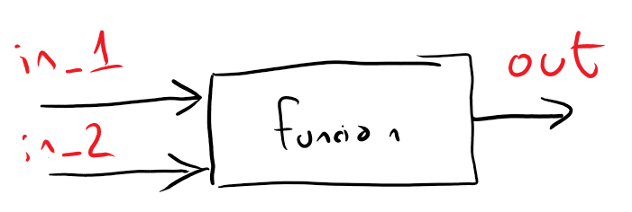

Definamos esta función que haga una simple suma:

```python
def funcion(in_1,in_2):
    out = in_1 + in_2
    return out
```

Si tratamos de ejecutar la función, no pasa nada, ya que lo que acabamos de hacer es definir la función, pero aún no la hemos utilizado.

Ahora para utilizarla:

```python
resultado = funcion(2,2)
print(resultado)
```

```
4
```

Las entradas de la función se definen en el paréntesis, la salida de la función se obtiene al ponerla al lado derecho de la igualdad, en este caso queda almacenada en la variable "resultado".

Lo interesante de las funciones es que son reutilizables.

### Usando fsolve

Para usar fsolve, debemos incluir el sistema de ecuaciones en una función de la siguiente forma:

```python
def manivelaCorredera(condIni, params):
    #variable de entrada y parámetros
    ## Primero la variable de entrada
    th2 = params[0]
    ## Luego los parámetros
    r2 = params[1]
    r3 = params[2]
    th4 = params[3]

    # las condiciones iniciales deben darse para que el método funcione
    th3 = condIni[0]
    r4 = condIni[1]

    # creamos el vector donde quedará la salida, inicialmente con ceros
    Y = np.zeros(2)
    # Definimos las ecuaciones escalares no lineales
    Y[0] = r2*np.cos(th2) - r3*np.cos(th3) - r4*np.cos(th4);
    Y[1] = r2*np.sin(th2) - r3*np.sin(th3) - r4*np.sin(th4);

    return Y
```

### Probar la función

Podemos probar la función simplemente definiendo los parámetros correspondientes al mecanismo, un valor para la variable de entrada y las condiciones iniciales:

```python
r2 = 5
r3 = 17.5
th4 = 0
print("los parámetros son: ")
print(r2,r3,th4)

th2 = np.deg2rad(0)
```

```
los parámetros son:
5 17.5 0
```

ahora para las condiciones iniciales, son valores aproximados de las incógnitas que debemos proveer como punto de partida para que fsolve inicie la búsqueda iterativa de la respuesta.

En este caso, podemos usar los valores exactos que obtuvimos con el método analítico, los cuales deberían hacer que las ecuaciones escalares se cumplan, es decir

Y[0] = $r2cos(\theta_{2})-r3cos(\theta_{3})-r4cos(\theta_{4})=0$

Y[1] = $r2sin(\theta_{2})-r3sin(\theta_{3})-r4sin(\theta_{4})=0$

que para $\theta_2 =$

```python
print(np.rad2deg(th2))
```

```
0.0
```

$r_4$ [cm] y $\theta_3$ [°] corresponden respectivamente a

```python
th3ini = np.deg2rad(180)
r4ini = 22.5
```

Por lo que si llamamos a la función

```python
x0 = [th3ini,r4ini]
parametros = [th2,r2,r3,th4]
print(manivelaCorredera(x0,parametros))
```

```
[ 0.0000000e+00 -2.1431319e-15]
```

Comprobamos que se cumplen las ecuaciones escalares para los valores de $r_4$ y $\theta_3$ propuestos.

Usualmente no vamos a tener valores exactos para las condiciones iniciales, por lo que podemos usar valores aproximados obtenidos por método gráfico.

#### ATENCIÓN

Si en este paso obtenemos valores muy diferentes a cero (con valores enteros mayores o menores a cero), debemos revisar varias cosas:

- las condiciones iniciales están muy alejadas de la realidad del mecanismo,
- las ecuaciones escalares están mal planteadas,
- los parámetros o la variable de entrada no corresponden con la posición analizada del mecanismo.

Resolver esto antes de continuar.

### Probar fsolve

Probemos fsolve de la siguiente forma

```python
q = fsolve(manivelaCorredera,x0, args = parametros)
print("Theta 3 = ",np.rad2deg(q[0])," y r4 = ",q[1])
```

```
Theta 3 =  180.0  y r4 =  22.5
```

Observemos que usando fsolve obtenemos lo que queremos hallar, es decir, los valores de las incógnitas. Sin embargo, en este caso no tiene mucha gracia que hayamos obtenido lo que ya conocíamos. Lo interesante viene después:

- conociendo una posición inicial del mecanismo, podemos hallar otras posiciones cercanas, por ejemplo, si movemos la manivela unos cuantos grados, por ejemplo

```python
incremento = 10 # grados
th2 = th2 + np.deg2rad(incremento)
# actualizamos el valor de la variable de entrada en el vector de parámetros
parametros[0] = th2
```

Ahora volvamos a resolver usando como condiciones iniciales el último resultado después de usar fsolve

```python
x0 = q
q = fsolve(manivelaCorredera,x0, args = parametros)
th3 = q[0]
r4 = q[1]
print("Theta 3 = ",np.rad2deg(th3)," y r4 = ",r4)
```

```
Theta 3 =  177.156173150156  y r4 =  22.40248714470529
```

Esto que acabamos de hacer lo podemos replicar para las posiciones del mecanismo que queramos, idealmente usando una estructura cíclica de programación, así podemos calcular el movimiento del mecanismo para un rango de valores de la variable de entrada.

Observémoslo gráficamente:

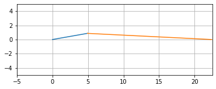

```python
import matplotlib.pyplot as plt

# Definición de puntos
Ox = 0
Oy = 0
Ax =  r2*np.cos(th2)
Ay =  r2*np.sin(th2)
Bx = puntoAx - r3*np.cos(th3)
By = puntoAy - r3*np.sin(th3)

# Gráfica del mecanismo en el plano

fig = plt.figure()
hr2 = plt.plot([Ox,Ax],[Oy,Ay])
hr3 = plt.plot([Ax,Bx],[Ay,By])
plt.axis("scaled")
plt.xlim(-r2,r2+r3)
plt.ylim(-r2,r2)
plt.grid()
plt.draw()
```

## Solución para un rango de valores

Es cuestión de usar una estructura cíclica de programación que nos permita ejecutar lo anterior varias veces.

Empecemos por definir cuántos valores queremos evaluar.

```python
numpos = 50
```

luego definimos las posiciones de la manivela con base en este valor. Una forma simple es definir "numpos" posiciones iniciando en 0° y terminando en 360°, distribuidas de forma lineal usando la función "linspace" de Numpy

```python
th2V = np.linspace(0,2*np.pi,numpos)
print(th2v)
```

```
[0.         0.12822827 0.25645654 0.38468481 0.51291309 0.64114136
 0.76936963 0.8975979  1.02582617 1.15405444 1.28228272 1.41051099
 1.53873926 1.66696753 1.7951958  1.92342407 2.05165235 2.17988062
 2.30810889 2.43633716 2.56456543 2.6927937  2.82102197 2.94925025
 3.07747852 3.20570679 3.33393506 3.46216333 3.5903916  3.71861988
 3.84684815 3.97507642 4.10330469 4.23153296 4.35976123 4.48798951
 4.61621778 4.74444605 4.87267432 5.00090259 5.12913086 5.25735913
 5.38558741 5.51381568 5.64204395 5.77027222 5.89850049 6.02672876
 6.15495704 6.28318531]
```

también debemos definir dónde vamos a almacenar los valores hallados

```python
th3V = np.zeros(numpos)
r4V = np.zeros(numpos)
```

adicionalmente, debemos crear un vector donde guardaremos información sobre la ejecución de fsolve, e.g., si hubo convergencia o si algo salió mal:

```python
exitflagV = np.zeros(numpos)
```

Ahora si, vamos a implementar un ciclo for para las "numpos" posiciones de la manivela

```python
for i in range(0,numpos):
    # para cada iteración actualizamos el valor de la variable de entrada
    parametros[0] = th2V[i]
    # resolvemos con fsolve
    q,info,exitflagV[i],mensaje = fsolve(manivelaCorredera,
                                        x0,
                                        args = parametros,
                                        full_output = True)
    th3V[i] = q[0]
    r4V[i] = q[1]
    x0 = q
    # Opcional, poner esto para detectar si hay un error
    if exitflagV[i] != 1:
        print('Error en la iteración ' + str(i))
        print(mensaje)
        break
```

Si todo salió bien, no debería salir nada, osea que podemos imprimir los valores de las incógnitas:

```python
print(np.rad2deg(th3V))
print(r4V)
```

```
[180.         177.90615636 175.84397443 173.84496392 171.94029026
 170.1605047  168.53516675 167.0923405  165.8579643  164.85511629
 164.10322405 163.61729097 163.40722681 163.47736961 163.82626713
 164.44675072 165.32629014 166.44757758 167.7892605  169.32673393
 171.03291049 172.8789073  174.83461413 176.8691328  178.95109764
 181.04890236 183.1308672  185.16538587 187.1210927  188.96708951
 190.67326607 192.2107395  193.55242242 194.67370986 195.55324928
 196.17373287 196.52263039 196.59277319 196.38270903 195.89677595
 195.14488371 194.1420357  192.9076595  191.46483325 189.8394953
 188.05970974 186.15503608 184.15602557 182.09384364 180.        ]
[22.5        22.44726576 22.2904562  22.0337035  21.68373717 21.24964897
 20.74256728 20.17524747 19.56159075 18.91611133 18.2533806  17.58748437
 16.93153341 16.29726579 15.69477136 15.13235399 14.61653008 14.15214537
 13.74258021 13.39000832 13.09567505 12.86016711 12.68365325 12.56608356
 12.50734065 12.50734065 12.56608356 12.68365325 12.86016711 13.09567505
 13.39000832 13.74258021 14.15214537 14.61653008 15.13235399 15.69477136
 16.29726579 16.93153341 17.58748437 18.2533806  18.91611133 19.56159075
 20.17524747 20.74256728 21.24964897 21.68373717 22.0337035  22.2904562
 22.44726576 22.5       ]
```

#### Nota:

Sabemos que todo salió bien porque los valores de Exitflag son todos 1. Si hay algún cero, algo salió mal en una posición de la barra de entrada.

```python
print(exitflagV)
```

```
[1. 1. 1. 1. 1. 1. 1. 1. 1. 1. 1. 1. 1. 1. 1. 1. 1. 1. 1. 1. 1. 1. 1. 1.
 1. 1. 1. 1. 1. 1. 1. 1. 1. 1. 1. 1. 1. 1. 1. 1. 1. 1. 1. 1. 1. 1. 1. 1.
 1. 1.]
```

Ya tenemos lo que queremos, ahora es cuestión de presentar la información. Por ahora generemos gráficas usando matplotlib.pyplot:

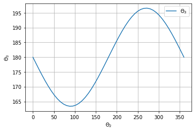

```python
plt.figure()
plt.plot(np.rad2deg(th2V),np.rad2deg(th3V))
plt.legend(["$\Theta_3$"])
plt.xlabel("$\Theta_2$")
plt.ylabel("$\Theta_3$")
plt.grid()
```

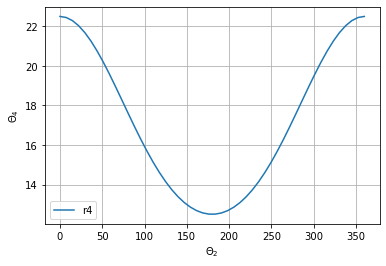

```python
plt.figure()
plt.plot(np.rad2deg(th2V),r4V)
plt.legend(["r4"])
plt.xlabel("$\Theta_2$")
plt.ylabel("$\Theta_4$")
plt.grid()
```

## Animación

Podemos hacer una representación gráfica del mecanismo donde observemos de manera dinámica las posiciones de las barras que acabamos de hallar.

### Definición de puntos

Para esto debemos hacer unos cambios sobre la definición de los puntos del mecanismo:

```python
# Los puntos fijos no se deben redefinir, en este caso el punto O
# El punto A y el punto B cambian de posición, por lo que se deben redefinir
AxV = r2*np.cos(th2V)
AyV = r2*np.sin(th2V)
BxV = AxV - r3*np.cos(th3V)
ByV = AyV - r3*np.sin(th3V)
print(ByV)
```

```
[-2.14313190e-15  9.99200722e-16  4.04121181e-14  9.39248679e-14
  1.46993528e-13  1.81632487e-13  1.92734717e-13  1.81188398e-13
  2.28261854e-13 -4.52970994e-14  8.88178420e-16  1.77635684e-15
  8.52651283e-14 -8.88178420e-16  3.55271368e-15 -3.55271368e-15
  8.88178420e-16 -1.42108547e-14 -3.77475828e-14 -6.30606678e-14
 -8.03801470e-14 -8.12683254e-14 -6.19504448e-14 -3.00870440e-14
 -8.60422844e-15  0.00000000e+00 -9.76996262e-15 -3.93018951e-14
 -6.79456491e-14 -8.26005930e-14 -8.34887715e-14 -6.35047570e-14
 -3.37507799e-14 -1.24344979e-14  8.88178420e-16  0.00000000e+00
 -2.66453526e-15 -8.88178420e-16  8.26005930e-14  8.88178420e-16
  8.88178420e-16 -3.81916720e-14  3.13971071e-13  2.04281037e-13
  2.10498285e-13  2.06501483e-13  1.61870517e-13  9.76996262e-14
  3.79696274e-14  4.40378247e-15]
```

### Preparación de animación

Para hacer animaciones haremos uso del módulo animation de matplotlib.

```python
from matplotlib.animation import FuncAnimation
```

Este módulo requiere también una función donde indiquemos qué se requiere animar, de esta forma:

```python
def animar(i):
    manivelaX = np.array([Ox,AxV[i]])
    manivelaY = np.array([Oy,AyV[i]])
    acopladorX = np.array([BxV[i],AxV[i]])
    acopladorY = np.array([ByV[i],AyV[i]])
    hr2[0].set_xdata(manivelaX)
    hr2[0].set_ydata(manivelaY)
    hr3[0].set_xdata(acopladorX)
    hr3[0].set_ydata(acopladorY)
```

Teniendo la función se puede realizar la animación:

```python
duracion = 3000 # en milisegundos
animacion = FuncAnimation(fig, animar, interval=duracion/numpos, save_count=numpos)
```

Ahora para mostrarla podemos usar varias formas:

1. generar un archivo .gif
2. mostrarla en un marco HTML5

En Jupyter funciona muy bien la opción 2:

```python
from IPython.display import HTML
HTML(animacion.to_html5_video())
```

[video not shown]

Si se desea generar un video para exportar la animación, descomente la siguiente línea:

```python
# animacion.save('mecanismo.mpg', writer="ffmpeg", fps=25, dpi=350)
```